# RPA AI Summit 2019

Trung Nguyen

5/25/2019

# 1 Overview

The training data set for the Rossman Store Sales consists of sales data for a set of 1115 stores across 942 days with **1050330** observations. In this project, the dataset is split to fit the 3 following cases:

# 2 Read data

Read train, test and submit sample data from input folder

```r
# set TryCatch for input folder (on kaggle kernel or local)

file2read.df <- c('test','train','store')

readinputs <- function(filename){
   assign(filename,
          tryCatch(fread(paste0("./input/",filename,".csv")),
                 error = function(e){
                   print('Detect working environment is not Kaggle kernel')
                   fread(paste0("../input/",filename,".csv"))
                 })
          ,envir = .GlobalEnv)
}

for (i in 1:length(file2read.df)){
  readinputs(file2read.df[i])
}
```

As stated in this official discussion [Link](https://www.kaggle.com/c/rossmann-store-sales/discussion/17048#96921), the codes bellow fixes the missing data. Then, the dataset is split into 2 parts to match the case description: 1. Pre 1.2015 2. Pre 6.2015

```r
test <- test %>% mutate(Open = replace(Open, which(Store == 622 &
                                             Date > as.Date('2015-09-04') &
                                             Date < as.Date('2015-09-18') &
                                             is.na(Open) == TRUE),0))

# Change type for "Date"
train$Date <- parse_date_time(train$Date,'%y-%m-%d') #lubridate pkg is fastest
test$Date <- parse_date_time(test$Date, '%y-%m-%d')

# Add and remove variables to test
tmp <- test %>%
  select(-Id) %>%
  mutate(Sales = 0,
         Customers = 0)

full <- rbind(train,tmp)

pre.1.15 <- full[Date < as_date('2015-01-01'),]
pre.6.15 <- full[Date < as_date('2015-06-01'),]
# remove unused dataset
rm(train,test,tmp)
```

# 3 Exploratory Data Analysis

Some of the charts were taken from [Exploratory Analysis Rossmann Kernel](https://www.kaggle.com/thie1e/exploratory-analysis-rossmann) with modifications. Explore histograms between sales and customers.

## 3.1 Pre 1.2015 (no stores data)

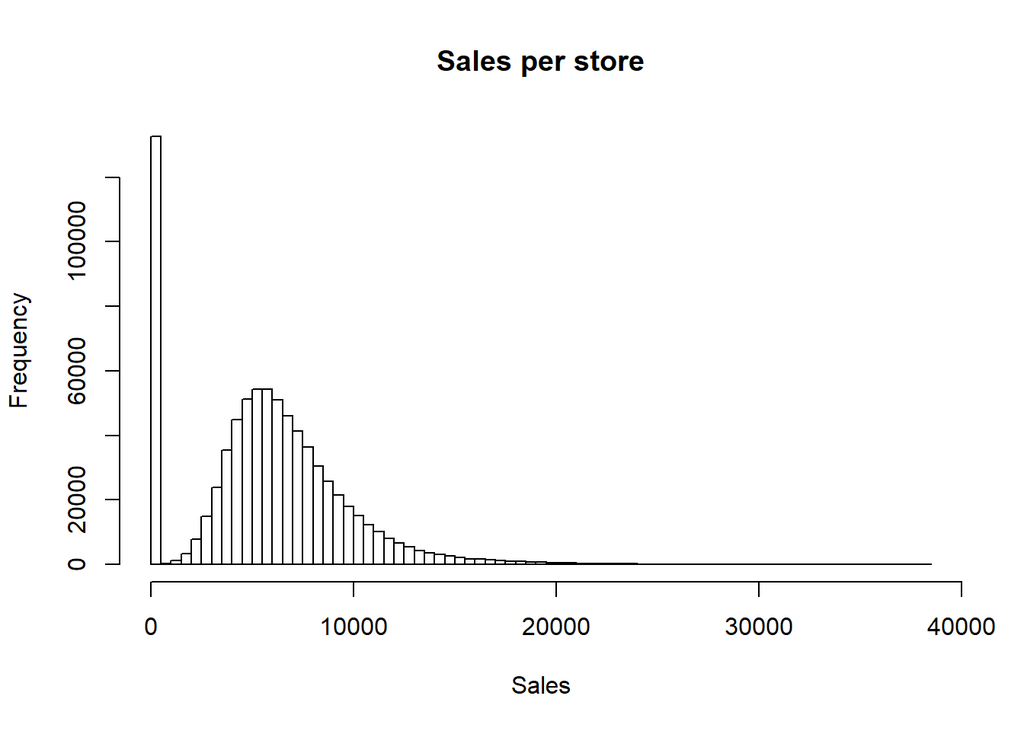

```r
# Sales histograms
hist(pre.1.15$Sales, 100,
     main = "Sales per store",
     xlab = "Sales")
```

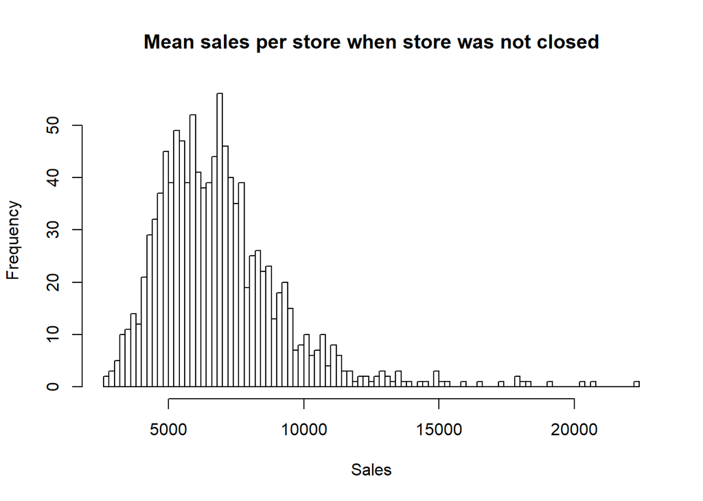

```r
hist(aggregate(pre.1.15[Sales != 0]$Sales,
               by = list(pre.1.15[Sales != 0]$Store), mean)$x, 100,
     main = "Mean sales per store when store was not closed",
     xlab = "Sales")
```

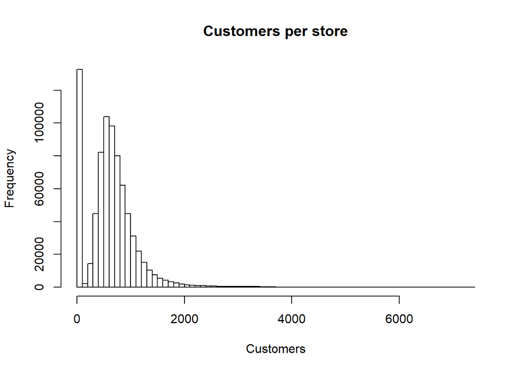

```r
# Customer histograms
hist(pre.1.15$Customers, 100,
     main = "Customers per store",
     xlab = "Customers")
```

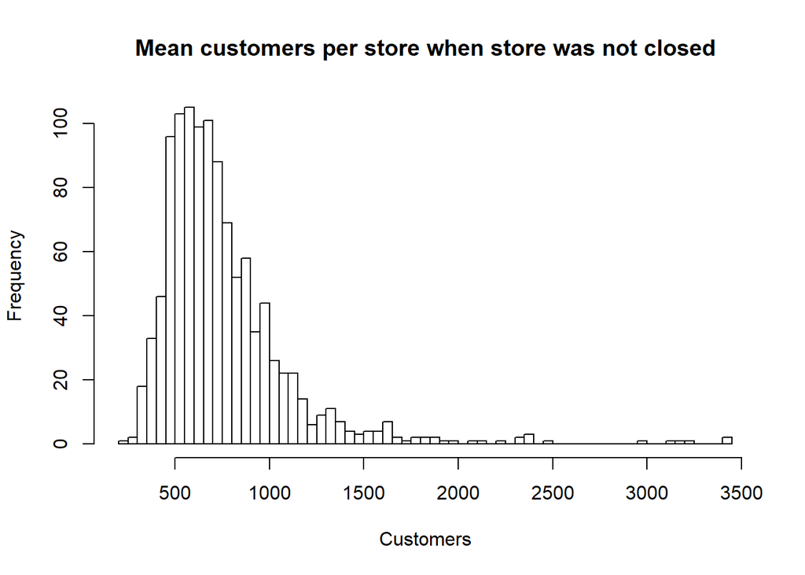

```r
hist(aggregate(pre.1.15[Sales != 0]$Customers,
               by = list(pre.1.15[Sales != 0]$Store), mean)$x, 100,
     main = "Mean customers per store when store was not closed",
     xlab = "Customers")
```

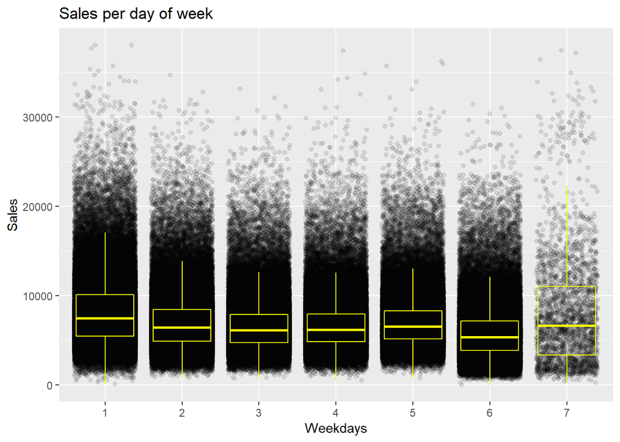

```r
# Sales per day of the week
ggplot(pre.1.15[Sales != 0],
       aes(x = factor(DayOfWeek), y = Sales)) +
    geom_jitter(alpha = 0.1) +
    geom_boxplot(color = "yellow", outlier.colour = NA, fill = NA) +
  labs(x = "Weekdays", title = "Sales per day of week")
```

## 3.2 Pre 1.2015 (w/t stores data)

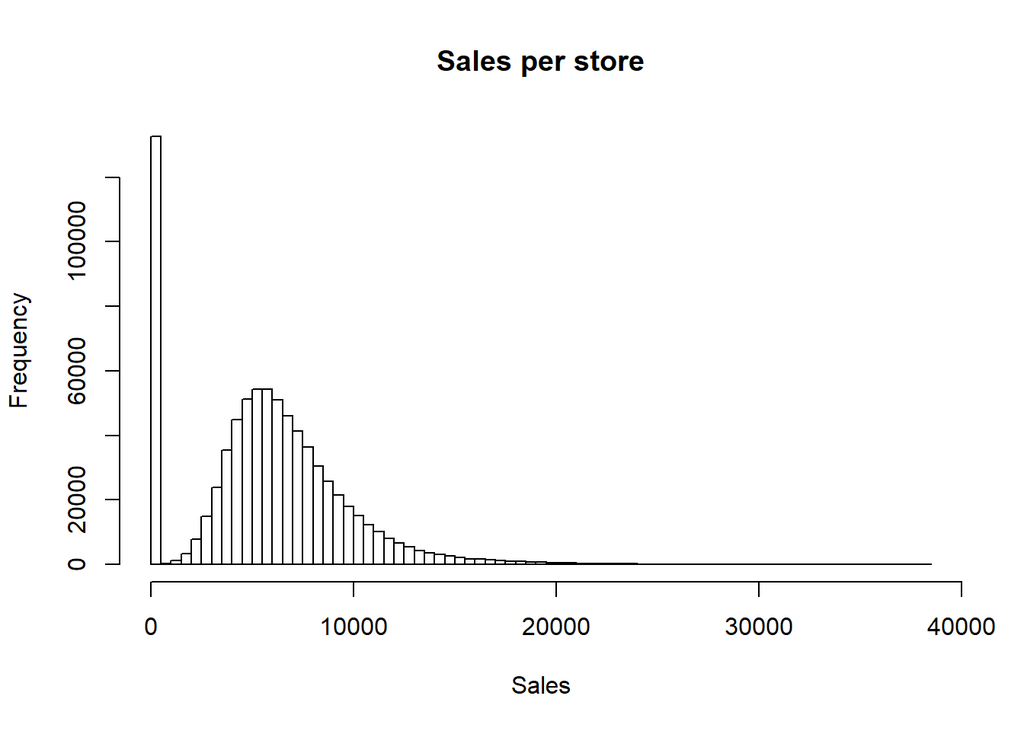

```r
# Sales histograms
hist(pre.1.15$Sales, 100,
     main = "Sales per store",
     xlab = "Sales")
```

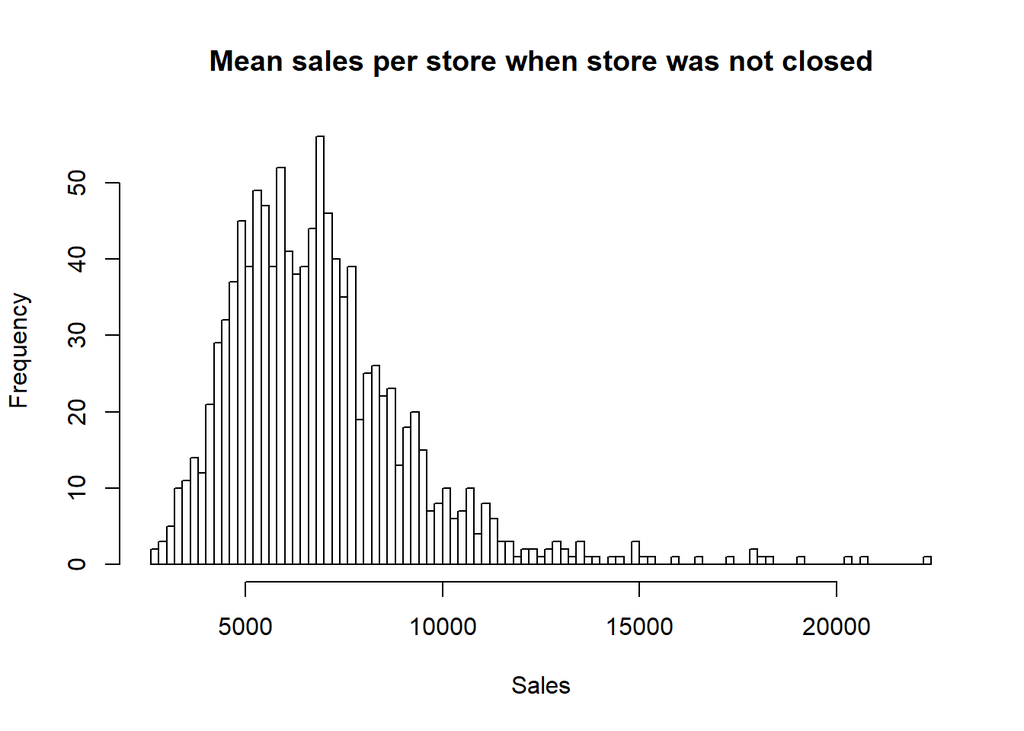

```r
hist(aggregate(pre.1.15[Sales != 0]$Sales,
               by = list(pre.1.15[Sales != 0]$Store), mean)$x, 100,
     main = "Mean sales per store when store was not closed",
     xlab = "Sales")
```

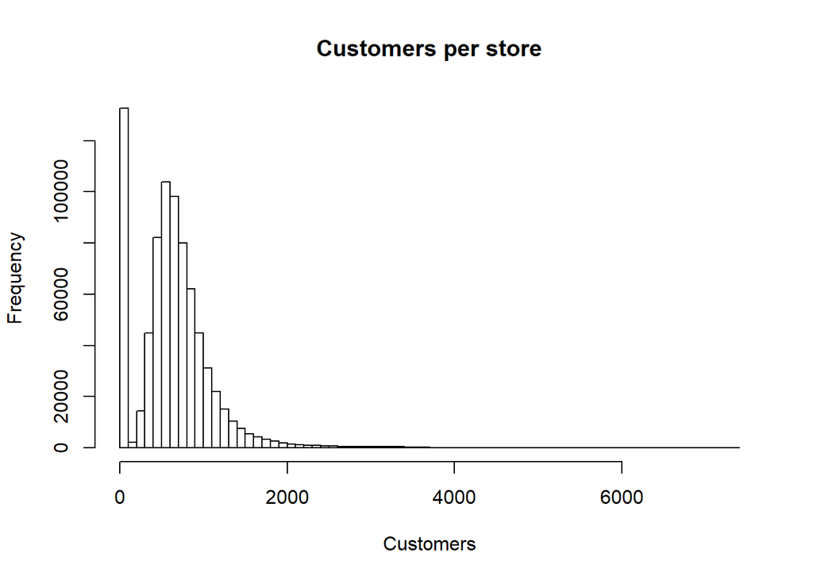

```r
# Customer histograms
hist(pre.1.15$Customers, 100,
     main = "Customers per store",
     xlab = "Customers")
```

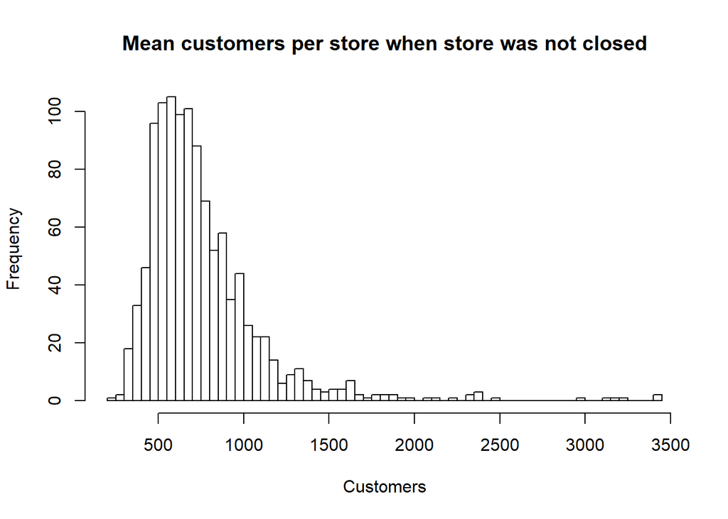

```r
hist(aggregate(pre.1.15[Sales != 0]$Customers,
               by = list(pre.1.15[Sales != 0]$Store), mean)$x, 100,
     main = "Mean customers per store when store was not closed",
     xlab = "Customers")
```

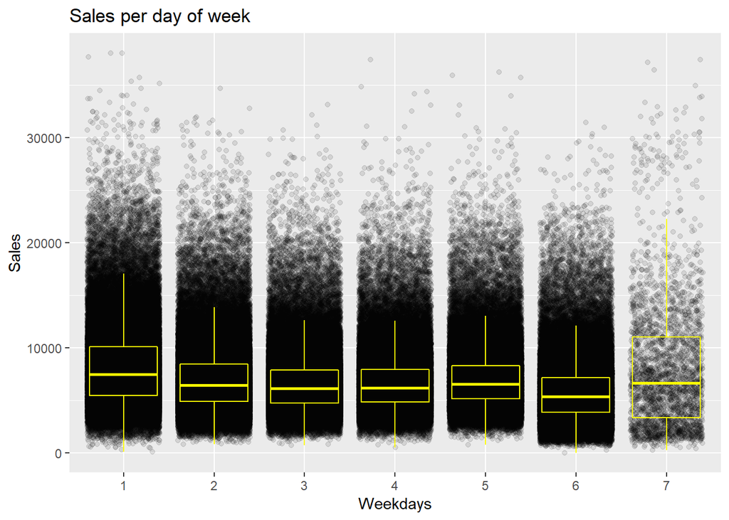

```r
# Sales per day of the week
ggplot(pre.1.15[Sales != 0],
       aes(x = factor(DayOfWeek), y = Sales)) +
    geom_jitter(alpha = 0.1) +
    geom_boxplot(color = "yellow", outlier.colour = NA, fill = NA) +
  labs(x = "Weekdays", title = "Sales per day of week")
```

```r
# Convert the CompetitionOpenSince... variables to one Date variable
store$CompetitionOpenSince <- as.yearmon(paste(store$CompetitionOpenSinceYear,
                                               store$CompetitionOpenSinceMonth, sep = "-"))
# Merge store and train (pre 1.2015)
store.1.15 <- store

store.1.15$CompetitionOpenSince[year(store$CompetitionOpenSince) >= 2015] <- NA
store.1.15$CompetitionOpenSinceMonth[store$CompetitionOpenSinceYear >= 2015] <- NA
store.1.15$CompetitionOpenSinceYear[store$CompetitionOpenSinceYear >= 2015] <- NA

pre.1.15_store <- merge(pre.1.15, store.1.15, by = "Store")

# Sales before and after competition opens
pre.1.15_store$DateYearmon <- as.yearmon(pre.1.15_store$Date)
pre.1.15_store <- pre.1.15_store[order(Date)]
timespan <- 100 # Days to collect before and after Opening of competition
beforeAndAfterComp <- function(s) {
    x <- pre.1.15_store[Store == s]
    daysWithComp <- x$CompetitionOpenSince >= x$DateYearmon
    if (any(!daysWithComp)) {
        compOpening <- head(which(!daysWithComp), 1) - 1
        if (compOpening > timespan & compOpening < (nrow(x) - timespan)) {
           x <- x[(compOpening - timespan):(compOpening + timespan), ]
            x$Day <- 1:nrow(x)
            return(x)
        }
    }
}
temp <- lapply(unique(pre.1.15_store[!is.na(CompetitionOpenSince)]$Store), beforeAndAfterComp)
temp <- do.call(rbind, temp)
# 147 stores first had no competition but at least 100 days before the end
# of the data set
length(unique(temp$Store))
```

```
## [1] 107
```

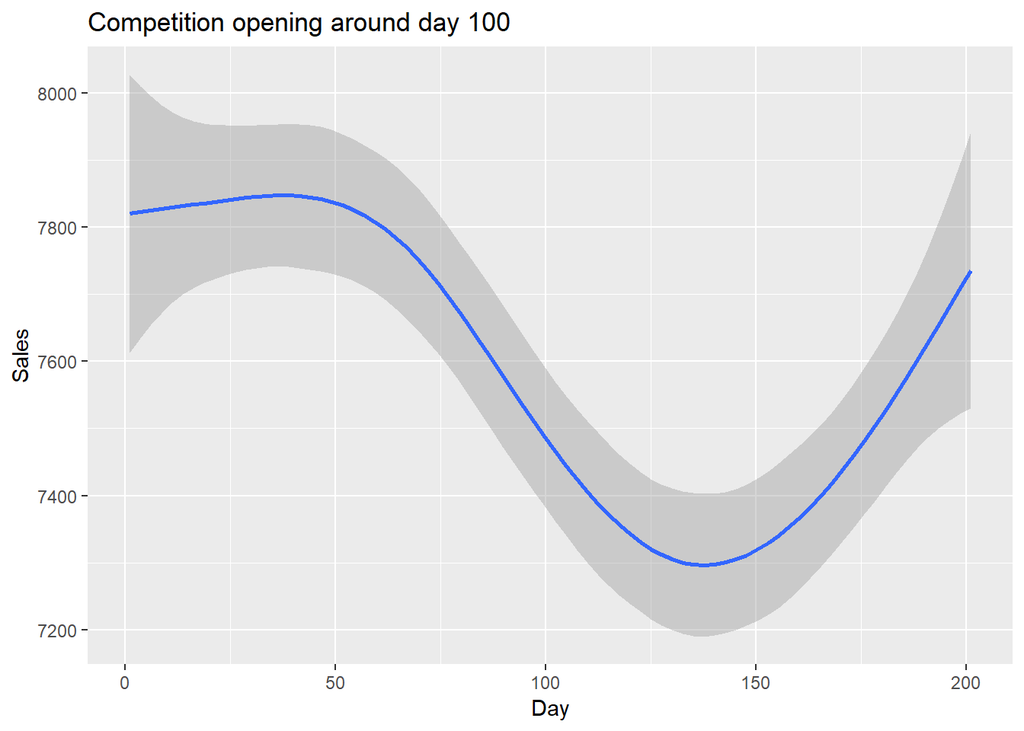

```r
ggplot(temp[Sales != 0], aes(x = Day, y = Sales)) +
    geom_smooth() +
    ggtitle(paste("Competition opening around day", timespan))
```

```r
rm(temp)
```

The different store types and assortment types imply different overall levels of sales and seem to be exhibiting different trends:

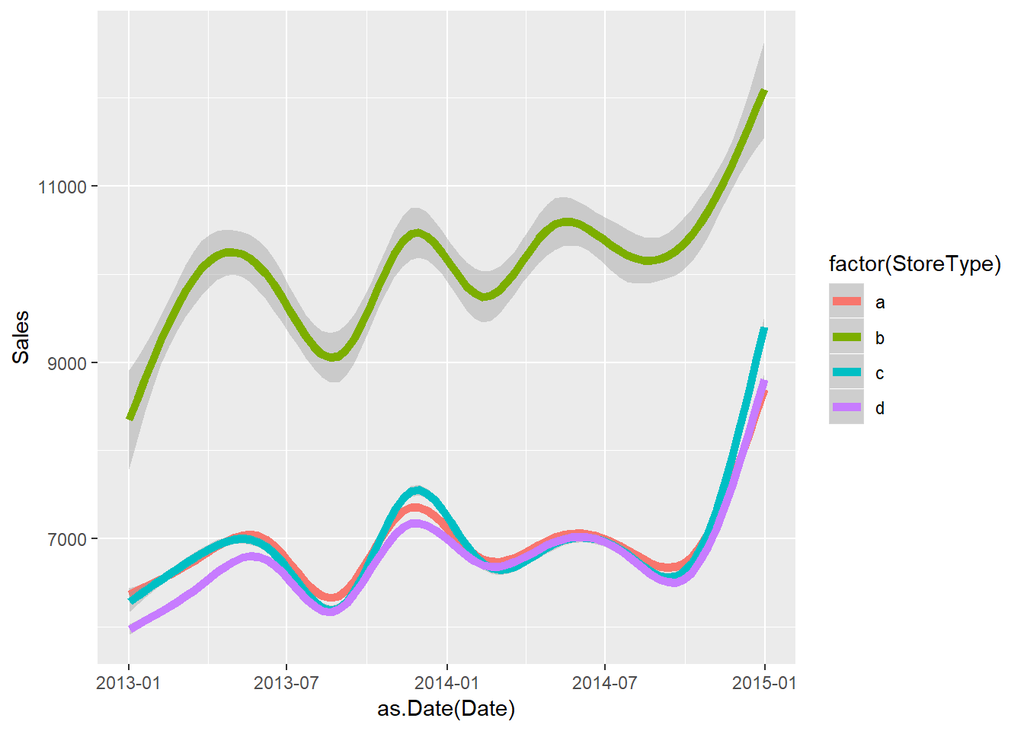

```r
ggplot(pre.1.15_store[Sales != 0],
       aes(x = as.Date(Date), y = Sales, color = factor(StoreType))) +
    geom_smooth(size = 2)
```

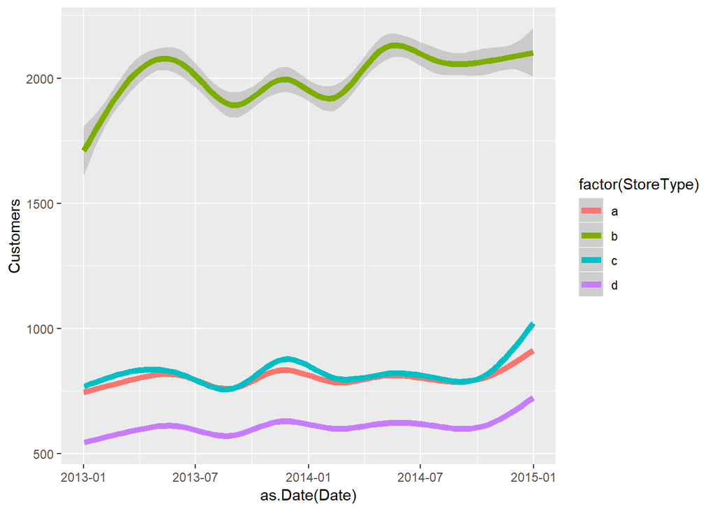

```r
ggplot(pre.1.15_store[Customers != 0],
       aes(x = as.Date(Date), y = Customers, color = factor(StoreType))) +
    geom_smooth(size = 2)
```

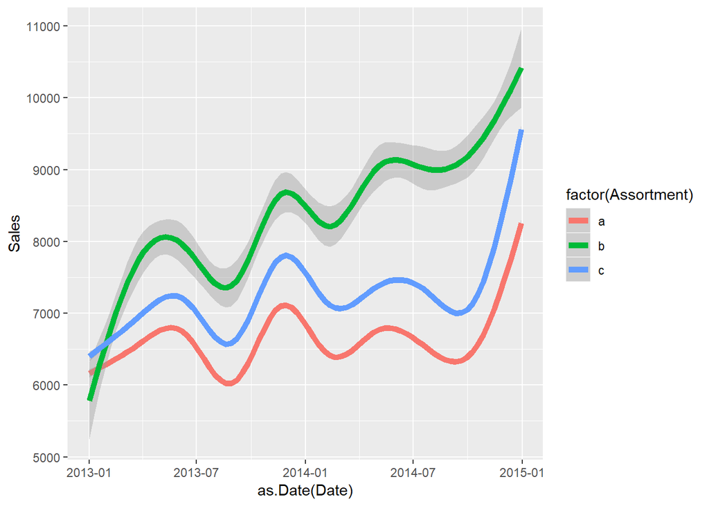

```r
ggplot(pre.1.15_store[Sales != 0],
       aes(x = as.Date(Date), y = Sales, color = factor(Assortment))) +
    geom_smooth(size = 2)
```

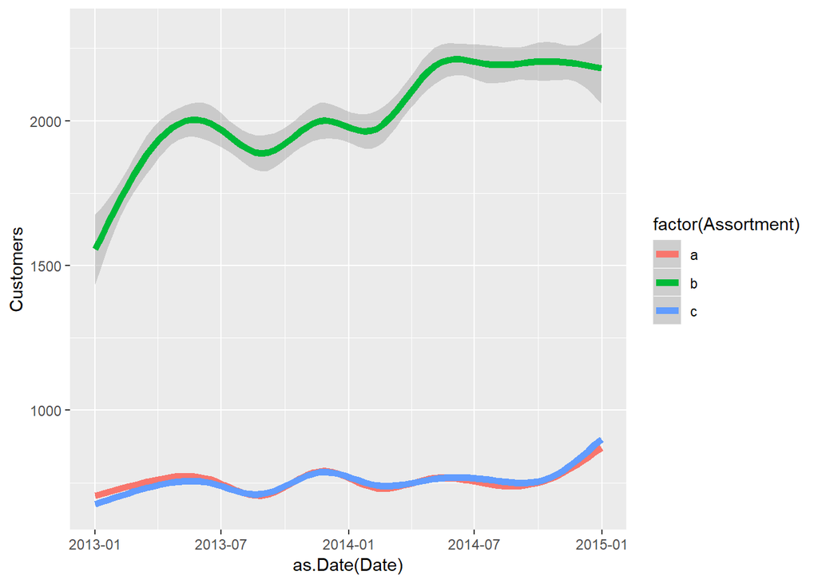

```r
ggplot(pre.1.15_store[Sales != 0],
       aes(x = as.Date(Date), y = Customers, color = factor(Assortment))) +
    geom_smooth(size = 2)
```

From the graph below, the relationship between ‘Competitor distance’ and ‘Sales’ is a little bit counterintuitive. We can see that the closer the competitors, the higher the sales. The reason might be that these shops are already in highly dense area (like shopping districts or main streets).

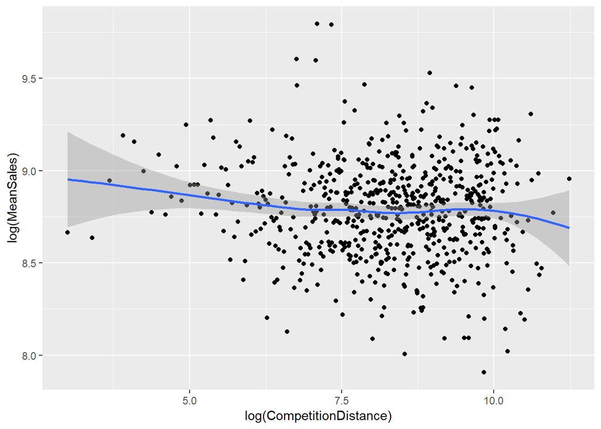

```r
salesByDist <- aggregate(pre.1.15_store[Sales != 0 & !is.na(CompetitionDistance)]$Sales,
               by = list(pre.1.15_store[Sales != 0 & !is.na(CompetitionDistance)]$CompetitionDistance), mean)

colnames(salesByDist) <- c("CompetitionDistance", "MeanSales")
ggplot(salesByDist, aes(x = log(CompetitionDistance), y = log(MeanSales))) +
    geom_point() + geom_smooth()
```

## 3.3 Pre 6.2015 (w/t stores data)

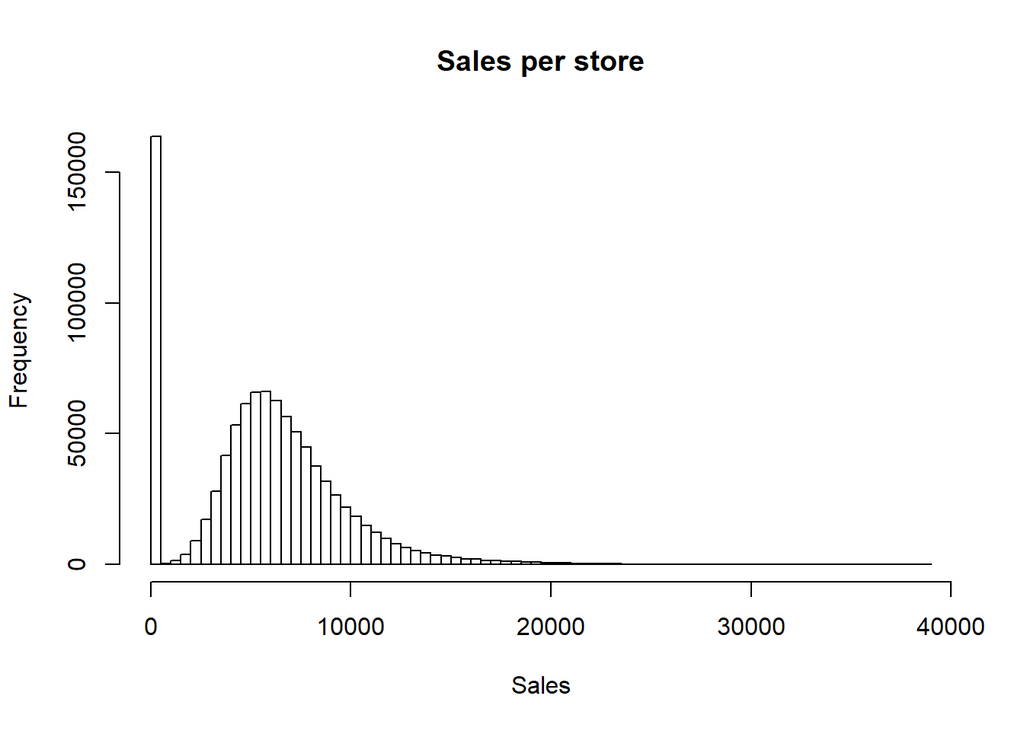

```r
# Sales histograms
hist(pre.6.15$Sales, 100,
     main = "Sales per store",
     xlab = "Sales")
```

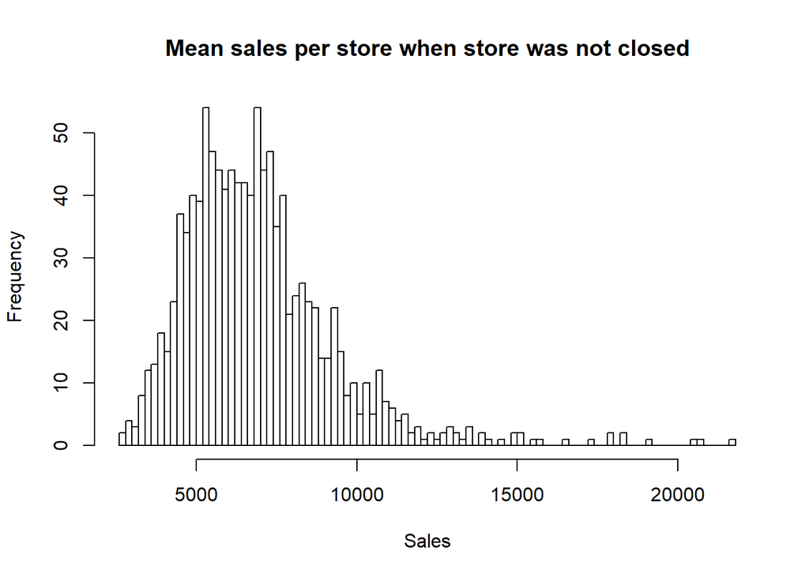

```r
hist(aggregate(pre.6.15[Sales != 0]$Sales,
               by = list(pre.6.15[Sales != 0]$Store), mean)$x, 100,
     main = "Mean sales per store when store was not closed",
     xlab = "Sales")
```

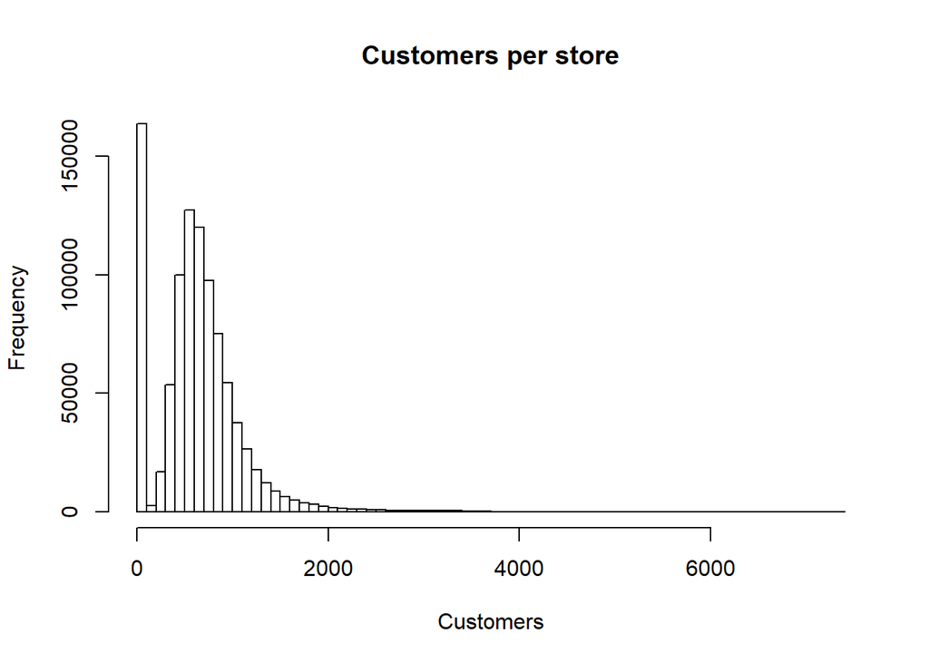

```r
# Customer histograms
hist(pre.6.15$Customers, 100,
     main = "Customers per store",
     xlab = "Customers")
```

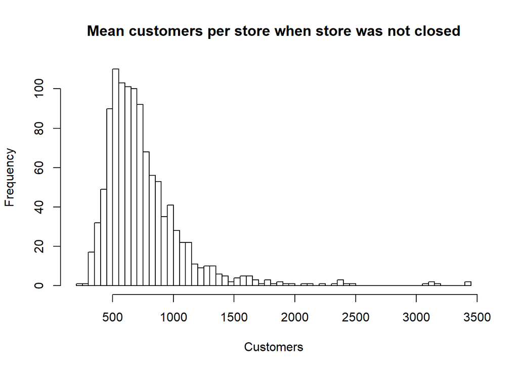

```r
hist(aggregate(pre.6.15[Sales != 0]$Customers,
               by = list(pre.6.15[Sales != 0]$Store), mean)$x, 100,
     main = "Mean customers per store when store was not closed",
     xlab = "Customers")
```

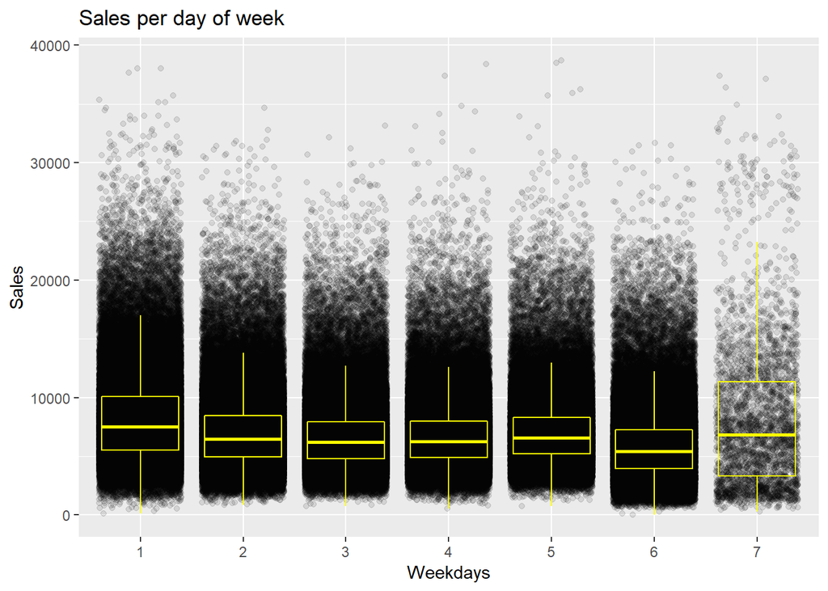

```r
# Sales per day of the week
ggplot(pre.6.15[Sales != 0],
       aes(x = factor(DayOfWeek), y = Sales)) +
    geom_jitter(alpha = 0.1) +
    geom_boxplot(color = "yellow", outlier.colour = NA, fill = NA) +
  labs(x = "Weekdays", title = "Sales per day of week")
```

```r
# Convert the CompetitionOpenSince... variables to one Date variable
store$CompetitionOpenSince <- as.yearmon(paste(store$CompetitionOpenSinceYear,
                                               store$CompetitionOpenSinceMonth, sep = "-"))

# Merge store and train (pre 6.2015)
store.6.15 <- store

store.6.15$CompetitionOpenSince[year(store$CompetitionOpenSince) >= 2015 & store.6.15$CompetitionOpenSinceMonth >= 6] <- NA
store.6.15$CompetitionOpenSinceMonth[store$CompetitionOpenSinceYear >= 2015 & store.6.15$CompetitionOpenSinceMonth >= 6] <- NA
store.6.15$CompetitionOpenSinceYear[store$CompetitionOpenSinceYear >= 2015 &
                                      (store.6.15$CompetitionOpenSinceMonth >= 6 |
                                         is.na(store.6.15$CompetitionOpenSinceMonth))] <- NA

pre.6.15_store <- merge(pre.6.15, store.6.15, by = "Store")
# remove the non-store 6.15
rm(pre.6.15)
# Sales before and after competition opens
pre.6.15_store$DateYearmon <- as.yearmon(pre.6.15_store$Date)
pre.6.15_store <- pre.6.15_store[order(Date)]
timespan <- 100 # Days to collect before and after Opening of competition
beforeAndAfterComp <- function(s) {
    x <- pre.6.15_store[Store == s]
    daysWithComp <- x$CompetitionOpenSince >= x$DateYearmon
    if (any(!daysWithComp)) {
        compOpening <- head(which(!daysWithComp), 1) - 1
        if (compOpening > timespan & compOpening < (nrow(x) - timespan)) {
           x <- x[(compOpening - timespan):(compOpening + timespan), ]
            x$Day <- 1:nrow(x)
            return(x)
        }
    }
}
temp <- lapply(unique(pre.6.15_store[!is.na(CompetitionOpenSince)]$Store), beforeAndAfterComp)
temp <- do.call(rbind, temp)
# 147 stores first had no competition but at least 100 days before the end
# of the data set
length(unique(temp$Store))
```

```
## [1] 141
```

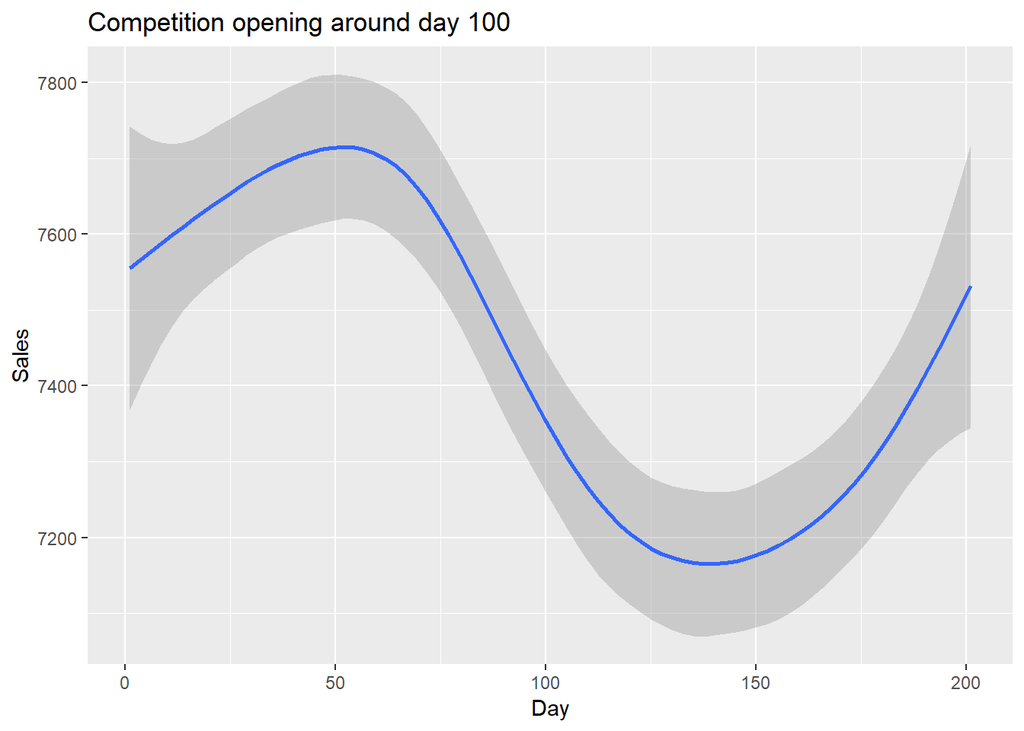

```r
ggplot(temp[Sales != 0], aes(x = Day, y = Sales)) +
    geom_smooth() +
    ggtitle(paste("Competition opening around day", timespan))
```

```r
rm(temp)
```

The different store types and assortment types imply different overall levels of sales and seem to be exhibiting different trends:

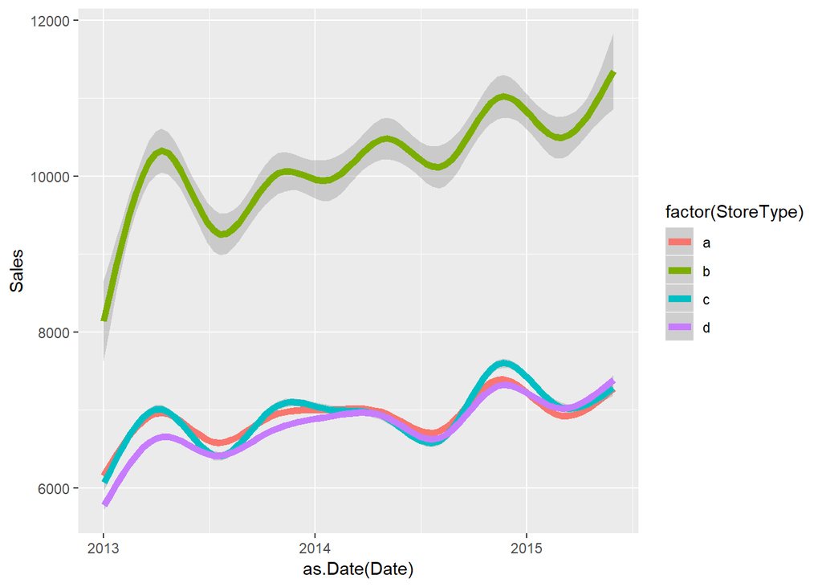

```r
ggplot(pre.6.15_store[Sales != 0],
       aes(x = as.Date(Date), y = Sales, color = factor(StoreType))) +
    geom_smooth(size = 2)
```

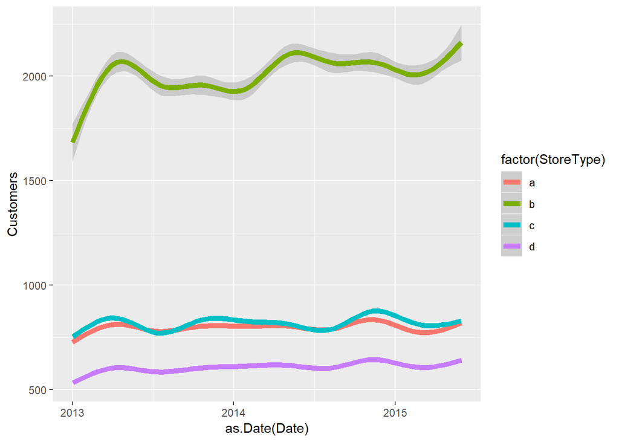

```r
ggplot(pre.6.15_store[Customers != 0],
       aes(x = as.Date(Date), y = Customers, color = factor(StoreType))) +
    geom_smooth(size = 2)
```

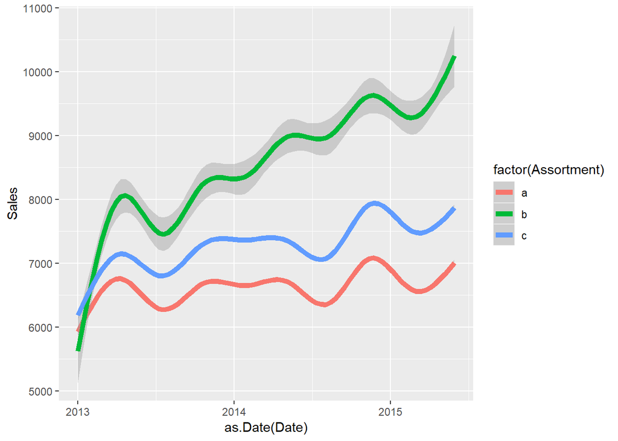

```r
ggplot(pre.6.15_store[Sales != 0],
       aes(x = as.Date(Date), y = Sales, color = factor(Assortment))) +
    geom_smooth(size = 2)
```

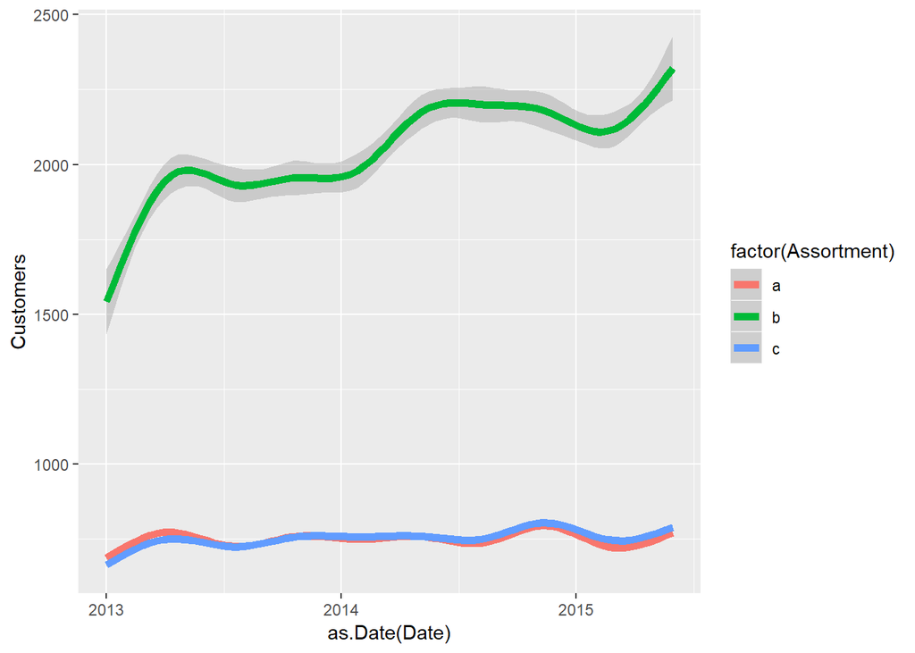

```r
ggplot(pre.6.15_store[Sales != 0],
       aes(x = as.Date(Date), y = Customers, color = factor(Assortment))) +
    geom_smooth(size = 2)
```

From the graph below, the relationship between ‘Competitor distance’ and ‘Sales’ is a little bit counterintuitive. We can see that the closer the competitors, the higher the sales. The reason might be that these shops are already in highly dense area (like shopping districts or main streets).

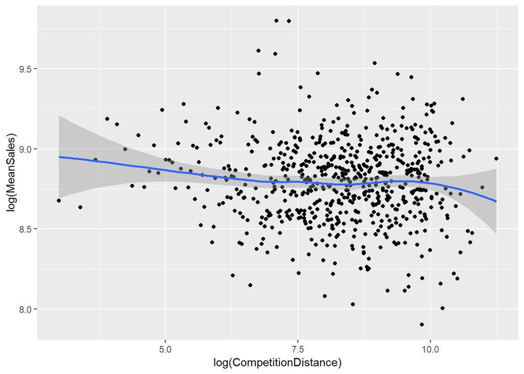

```r
salesByDist <- aggregate(pre.6.15_store[Sales != 0 & !is.na(CompetitionDistance)]$Sales,
               by = list(pre.6.15_store[Sales != 0 & !is.na(CompetitionDistance)]$CompetitionDistance), mean)

colnames(salesByDist) <- c("CompetitionDistance", "MeanSales")
ggplot(salesByDist, aes(x = log(CompetitionDistance), y = log(MeanSales))) +
    geom_point() + geom_smooth()
```

# 4 Feature Engineering

## 4.1 Logs transformation

- Since the data spans accross a large timeline, it is better to perform some transformation on the target variable. Here I pick “Log Transform”

```r
full <- full %>%
  mutate(LogSales = log1p(Sales))

full_store <- merge(full, store, by = "Store")

pre.1.15 <- pre.1.15 %>%
  mutate(LogSales = log1p(Sales))
pre.1.15_store <- pre.1.15_store %>%
  mutate(LogSales = log1p(Sales))
pre.6.15_store <- pre.6.15_store %>%
  mutate(LogSales = log1p(Sales))
```

## 4.2 States as a feature

- Since the stores locations are scattered in **GERMANY**, it is likely that multiple stores would have different *“StateHoliday”*. However, inspired from this repository in Python of @gereleth [Putting stores on map](https://gist.github.com/gereleth/781a92c97b58b07a11e2#file-putting_stores_on_map-ipynb), I decided to adopt the code and translate into R to add *states* as a feature to our dataset.
- External sources:
  - Public holidays data: http://www.timeanddate.com/holidays/germany/2013
  - School holidays data: http://www.holidays-info.com/School-Holidays-Germany/2015/school-holidays_2015.html Start by grouping and cross-referencing stores with State Holidays data

```r
# Overview of public holiday dates and numbers of stores celebrating
holiday <- full %>% filter(StateHoliday == 'a')

## Saxony (SN) - Repentance Day (20-11-2013)
SN <- holiday %>% filter(Date == ymd("2013-11-20"))

## BW_BY_ST - Epiphany (06-01-2013)
BW_BY_ST <- holiday %>% filter(Date == ymd("2013-01-06"))

## BW_BY_HE_NW_RP_SL - Corpus Christi (30-05-2013) (also with SN)
BW_BY_HE_NW_RP_SL <- holiday %>% filter(Date == ymd("2013-05-30"))
# Remove SN from the list
BW_BY_HE_NW_RP_SL <- anti_join(BW_BY_HE_NW_RP_SL,SN, by = "Store")

## BY_SL - Assumption of Mary (15-08-2013)
BY_SL <- holiday %>% filter(Date == ymd("2013-08-15"))

## BB_MV_SN_ST_TH - Reformation day (31-10-2013)
BB_MV_SN_ST_TH <- holiday %>% filter(Date == ymd("2013-10-31"))

## BW_BY_NW_RP_SL- All Saint's Day (01-11-2013)
BW_BY_NW_RP_SL <- holiday %>% filter(Date == ymd("2013-11-01"))

# Intersecting and Setxoring to split states
BW_BY <- semi_join(BW_BY_ST, BW_BY_HE_NW_RP_SL, by = "Store")
ST <- anti_join(BW_BY_ST, BW_BY, by = "Store")
BY <- semi_join(BW_BY, BY_SL, by = "Store")
SL <- anti_join(BY, BY_SL, by = "Store")
BW <- anti_join(BW_BY,BY, by = "Store")
HE <- anti_join(BW_BY_HE_NW_RP_SL, BW_BY_NW_RP_SL, by = "Store")
BB_MV_TH <- anti_join(anti_join(BB_MV_SN_ST_TH, SN, by = "Store"),ST, by = "Store")
NW_RP <- anti_join(BW_BY_NW_RP_SL, BW_BY, by = "Store")

allstores <- full %>% distinct(Store) # get all stores ID
BE_HB_HH_NI_SH <- anti_join(anti_join(allstores, BW_BY_HE_NW_RP_SL, by = "Store"), BB_MV_SN_ST_TH, by = "Store")
```

Now using school holiday to further intersecting and setoxring to cluster stores into states

```r
# 26-03-2015 is a school holiday in RP but now NW
RP <- full %>%
  filter(Date == ymd("2015-03-26") & SchoolHoliday == 1) %>%
  semi_join(NW_RP, by = "Store")
NW <- anti_join(NW_RP, RP, by = "Store")

# Winter holidays not lasting till Feb 14th rule out MV.
# Easter holidays starting on Mar 30th suggest TH.
# Confirmed by summer holidays starting on Jul 13th.
TH <- BB_MV_TH

# Only HH has easter holidays on Mar 2nd. And on May 5th.
HH <- full %>%
  filter(Date ==ymd("2015-03-02") & SchoolHoliday == 1) %>%
  semi_join(BE_HB_HH_NI_SH, by = "Store")

BE_HB_NI_SH <- anti_join(BE_HB_HH_NI_SH, HH, by = "Store")
# Only SH has holidays on Apr 17th. And on Feb 2nd.
SH <- full %>%
  filter(Date == ymd("2015-04-17") & SchoolHoliday == 1) %>%
  semi_join(BE_HB_NI_SH, by = "Store")

BE_HB_NI <- anti_join(BE_HB_NI_SH, SH, by = "Store")

#  Mar 25th is not a holiday in BE.
BE <- full %>%
  filter(Date == ymd("2015-03-25") & SchoolHoliday == 1) %>%
  semi_join(BE_HB_NI, by = "Store")

HB_NI <- anti_join(BE_HB_NI, BE, by = "Store")
```

```r
#### Saving results to "store" df
store <-store %>%
  mutate(States = case_when(
    Store %in% intersect(store$Store, BW$Store) ~ "BW",
    Store %in% intersect(store$Store, BY$Store) ~ "BY",
    Store %in% intersect(store$Store, BE$Store) ~ "BE",
    Store %in% intersect(store$Store, HB_NI$Store) ~ "HB, NI",
    Store %in% intersect(store$Store, HH$Store) ~ "HH",
    Store %in% intersect(store$Store, HE$Store) ~ "HE",
    Store %in% intersect(store$Store, NW$Store) ~ "NW",
    Store %in% intersect(store$Store, RP$Store) ~ "RP",
    Store %in% intersect(store$Store, SN$Store) ~ "SN",
    Store %in% intersect(store$Store, ST$Store) ~ "ST",
    Store %in% intersect(store$Store, SH$Store) ~ "SH",
    Store %in% intersect(store$Store, TH$Store) ~ "TH"))

# clean datasets
rm(BW,BY,BE,HB_NI,HH,HE,NW,RP,SN,ST,SH,TH,SL, allstores)
rm(BB_MV_SN_ST_TH, BB_MV_TH, BE_HB_HH_NI_SH, BE_HB_NI, BE_HB_NI_SH,
   BW_BY, BW_BY_HE_NW_RP_SL, BW_BY_NW_RP_SL, BW_BY_ST, BY_ST,
   BY_SL, NW_RP, holiday)
# Update store datasets for 1.15 and 6.15
store.1.15 <- store.1.15 %>%
  inner_join(store %>% select(Store, States))
store.6.15 <- store.6.15 %>%
  inner_join(store %>% select(Store, States))
```

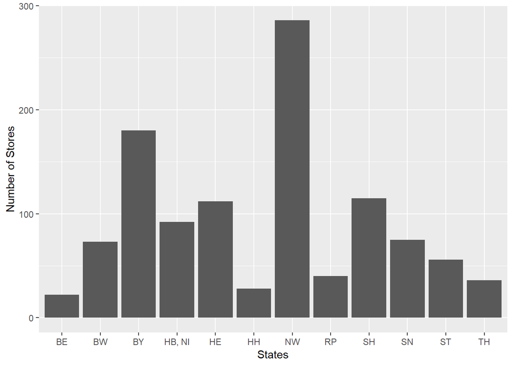

```r
# Plot results
tmp <-store %>%
  semi_join(full, by = "Store") %>%
  select(Store, States) %>%
  group_by(States) %>%
  tally()

ggplot(tmp, aes(States, n)) +
  geom_bar(stat="identity", position = "dodge") +
  scale_fill_brewer(palette = "Set1") +
  labs(y = "Number of Stores")
```

```r
rm(tmp)
```

# 5 Algorithm Developments

In this demonstration, I will use only “Distributed Random Forest” (DRF) from H2O package to forecast the sales in all cases. This is the most popular and also the “winning” algorithm in the Kaggle competition of Rossmann sales prediction in 2017.

## 5.1 Case 1

Pre.1.15 without store features.

```r
# Split data to 70-30 with temporal dimension(rule of thumb)
x <- max(pre.1.15$Date) - min(pre.1.15$Date)
x <- floor(x * 0.7) %>% as.numeric() # 510 days

train.pre.1.15 <- pre.1.15 %>%
  filter(Date <= as.Date(min(pre.1.15$Date)) + x)
test.pre.1.15 <- pre.1.15 %>%
  filter(Date > as.Date(min(pre.1.15$Date)) + x)

# Create "features" sets
## Set up variable to use all features other than those specified here
col2remove <- c("Id","Date",
                "Sales",
                "Customers")

# Filter only features for pre.1.15 dataset
features <- colnames(pre.1.15)[!(colnames(pre.1.15) %in% col2remove)]
train.pre.1.15 <- train.pre.1.15 %>% select(features)
test.pre.1.15 <- test.pre.1.15 %>% select(features)

# There are some NAs in the integer columns so conversion to zero
train.pre.1.15[is.na(train.pre.1.15)]   <- 0
test.pre.1.15[is.na(test.pre.1.15)]   <- 0
```

With the dedicated train and test datasets, DRF build a model with RMSE **0.24**.

```r
library(h2o)

h2o.init(nthreads=-1,
         max_mem_size = '6G')

h2o.show_progress()

trainHex <- as.h2o(train.pre.1.15)
testHex <- as.h2o(test.pre.1.15)

# run with default first
rfHex <- h2o.randomForest(x = features,
                          y = "LogSales",
                          ntrees = 150, # default is 50
                          nbins_cats = 1115, # for 1115 stores
                          training_frame = trainHex,
                          validation_frame = testHex)
```

```r
h2o.no_progress()
print(paste0('Case 1 - RMSE of model: ',round(h2o.rmse(rfHex),2)))
```

```
## [1] "Case 1 - RMSE of model: 0.24"
```

```r
# Predict for 2.2015
predict.Jan.2015 <- full %>% filter(Date < as_date("2015-02-01") & Date > as_date("2014-12-31"))
features.pred <- features[features !="LogSales"]
predict.Jan.2015Hex <- as.h2o(predict.Jan.2015 %>% select(features.pred))



# Run model on full set pre.1.15
full.pre.1.15 <- pre.1.15 %>% select(features)
pre.1.15Hex <- as.h2o(full.pre.1.15)

rfHex.fc <- h2o.randomForest(x = features,
                             y = "LogSales",
                             ntrees = 150, # default is 50
                             nbins_cats = 1115,
                             training_frame = pre.1.15Hex)

## Get predictions out; predicts in H2O, as.data.frame gets them into R
predictions <- as.data.frame(h2o.predict(rfHex.fc,
                                         predict.Jan.2015Hex))
## Return the predictions to the original scale of the Sales data
pred <- expm1(predictions[,1])

# Compare to the real results
print(paste0('Case 1 - RMSE compare to Jan 2015: ',round(ModelMetrics::rmse(predict.Jan.2015$LogSales, predictions$predict),2)))
```

```
## [1] "Case 1 - RMSE compare to Jan 2015: 0.21"
```

## 5.2 Case 2

Pre.1.15 with store features.

```r
# Split data to 70-30 with temporal dimension(rule of thumb)
x <- max(pre.1.15_store$Date) - min(pre.1.15_store$Date)
x <- floor(x * 0.7) %>% as.numeric() # 510 days

train.pre.1.15_store <- pre.1.15_store %>%
  filter(Date <= as.Date(min(pre.1.15_store$Date)) + x)
test.pre.1.15_store <- pre.1.15_store %>%
  filter(Date > as.Date(min(pre.1.15_store$Date)) + x)

# Create "features" sets
## Set up variable to use all features other than those specified here
col2remove <- c("Id","Date",
                "Sales",
                "DateYearmon",
                "CompetitionOpenSince",
                #"logSales",
                "Customers",
                "CompetitionDistance",
                "CompetitionOpenSinceMonth",
                "CompetitionOpenSinceYear",
                "Promo2SinceWeek",
                "Promo2SinceYear",
                "PromoInterval",
                "CompetitionEntrance")
# Filter only features for pre.1.15_store dataset
features <- colnames(pre.1.15_store)[!(colnames(pre.1.15_store) %in% col2remove)]
train.pre.1.15_store <- train.pre.1.15_store %>% select(features)
test.pre.1.15_store <- test.pre.1.15_store %>% select(features)

# There are some NAs in the integer columns so conversion to zero
train.pre.1.15_store[is.na(train.pre.1.15_store)]   <- 0
test.pre.1.15_store[is.na(test.pre.1.15_store)]   <- 0
```

With the dedicated train and test datasets, DRF build a model with RMSE **0.2**.

```r
library(h2o)

h2o.init(nthreads=-1,
         max_mem_size = '6G')

h2o.show_progress()
trainHex <- as.h2o(train.pre.1.15_store)
testHex <- as.h2o(test.pre.1.15_store)

# run with default first
rfHex <- h2o.randomForest(x = features,
                          y = "LogSales",
                          ntrees = 150, # default is 50
                          nbins_cats = 1115, # for 1115 stores
                          training_frame = trainHex,
                          validation_frame = testHex)
```

```r
h2o.no_progress()
print(paste0('Case 2 - RMSE of model: ',round(h2o.rmse(rfHex),2)))
```

```
## [1] "Case 2 - RMSE of model: 0.2"
```

```r
# Predict for 2.2015
predict.Jan.2015 <- full_store %>% filter(Date < as_date("2015-02-01") & Date > as_date("2014-12-31"))
features.pred <- features[features !="LogSales"]
predict.Jan.2015Hex <- as.h2o(predict.Jan.2015 %>% select(features.pred))


# Run model on full set pre.1.15_store
full.pre.1.15_store <- pre.1.15_store %>% select(features)
pre.1.15_storeHex <- as.h2o(full.pre.1.15_store)

rfHex.fc <- h2o.randomForest(x = features,
                             y = "LogSales",
                             ntrees = 150, # default is 50
                             nbins_cats = 1115,
                             training_frame = pre.1.15_storeHex)

## Get predictions out; predicts in H2O, as.data.frame gets them into R
predictions <- as.data.frame(h2o.predict(rfHex.fc,
                                         predict.Jan.2015Hex))
## Return the predictions to the original scale of the Sales data
pred <- expm1(predictions[,1])

# Compare to the real results
print(paste0('Case 2 - RMSE of prediction for Jan 2015: ',round(ModelMetrics::rmse(predict.Jan.2015$LogSales, predictions$predict),2)))
```

```
## [1] "Case 2 - RMSE of prediction for Jan 2015: 0.17"
```

## 5.3 Case 3

Now with the timestamp at 6 months later (May 2015). We would like to update our ML algorithm with the new data of 6 months Pre.6.15 with store features.

```r
# Split data to 70-30 with temporal dimension(rule of thumb)
x <- max(pre.6.15_store$Date) - min(pre.6.15_store$Date)
x <- floor(x * 0.7) %>% as.numeric() # 510 days

train.pre.6.15_store <- pre.6.15_store %>%
  filter(Date <= as.Date(min(pre.6.15_store$Date)) + x)
test.pre.6.15_store <- pre.6.15_store %>%
  filter(Date > as.Date(min(pre.6.15_store$Date)) + x)

# Create "features" sets
## Set up variable to use all features other than those specified here
col2remove <- c("Id","Date",
                "Sales",
                "DateYearmon",
                "CompetitionOpenSince",
                #"logSales",
                "Customers",
                "CompetitionDistance",
                "CompetitionOpenSinceMonth",
                "CompetitionOpenSinceYear",
                "Promo2SinceWeek",
                "Promo2SinceYear",
                "PromoInterval",
                "CompetitionEntrance")
# Filter only features for pre.6.15_store dataset
features <- colnames(pre.6.15_store)[!(colnames(pre.6.15_store) %in% col2remove)]
train.pre.6.15_store <- train.pre.6.15_store %>% select(features)
test.pre.6.15_store <- test.pre.6.15_store %>% select(features)

# There are some NAs in the integer columns so conversion to zero
train.pre.6.15_store[is.na(train.pre.6.15_store)]   <- 0
test.pre.6.15_store[is.na(test.pre.6.15_store)]   <- 0
```

With the dedicated train and test datasets, DRF build a model with RMSE **0.2**.

```r
library(h2o)

h2o.init(nthreads=-1,
         max_mem_size = '6G')

h2o.show_progress()
trainHex <- as.h2o(train.pre.6.15_store)
testHex <- as.h2o(test.pre.6.15_store)

# run with default first
rfHex <- h2o.randomForest(x = features,
                          y = "LogSales",
                          ntrees = 150, # default is 50
                          nbins_cats = 1115, # for 1115 stores
                          training_frame = trainHex,
                          validation_frame = testHex)
```

```r
h2o.no_progress()
print(paste0('Case 3 - RMSE of model: ',round(h2o.rmse(rfHex),2)))
```

```
## [1] "Case 3 - RMSE of model: 0.2"
```

```r
# Predict for 6.2015
predict.June.2015 <- full_store %>% filter(Date < as_date("2015-07-01") & Date > as_date("2015-05-31"))
features.pred <- features[features !="LogSales"]
predict.June.2015Hex <- as.h2o(predict.June.2015 %>% select(features.pred))


# Run model on full set pre.6.15_store
full.pre.6.15_store <- pre.6.15_store %>% select(features)
pre.6.15_storeHex <- as.h2o(full.pre.6.15_store)

rfHex.fc <- h2o.randomForest(x = features,
                             y = "LogSales",
                             ntrees = 150, # default is 50
                             nbins_cats = 1115,
                             training_frame = pre.6.15_storeHex)

## Get predictions out; predicts in H2O, as.data.frame gets them into R
predictions <- as.data.frame(h2o.predict(rfHex.fc,
                                         predict.June.2015Hex))
## Return the predictions to the original scale of the Sales data
pred <- expm1(predictions[,1])

# Compare to the real results
print(paste0('Case 3 - RMSE of prediction for June 2015: ',round(ModelMetrics::rmse(predict.June.2015$LogSales, predictions$predict),2)))
```

```
## [1] "Case 3 - RMSE of prediction for June 2015: 0.17"
```